# Identification of Adolescents at Risk for Suicide Attempt

# Training and Evaluating Neural Network Models

The following code trains and evaluates neural network models. I trained each set of models using four training datasets: 1) original training data with class weights described above, 2) training data with random undersampling of the majority class, 3) training data with random oversampling of the minority class, and 4) training data resampled using SMOTE + TOMEK.

Note that this code has been updated since the final presentation, so the values presented differ from those in the final presentation. I was able to increase the specificity slightly at a sensitivity of 0.92 compared to that presented in the final presentation.

The initial model trained for each dataset included one hidden layer with neurons equal to the mean of the neuron number in the input (n=478) and the output layer (n=1), which I rounded to 240. This was based on a recommendation online (although perhaps not fully applicable to this model, but, as a novice, it seemed as good of a starting point as any) that: "In sum, for most problems, one could probably get decent performance (even without a second optimization step) by setting the hidden layer configuration using just two rules: (i) number of hidden layers equals one; and (ii) the number of neurons in that layer is the mean of the neurons in the input and output layers." (Source: https://stats.stackexchange.com/questions/181/how-to-choose-the-number-of-hidden-layers-and-nodes-in-a-feedforward-neural-netw)

I then edited the following hyperparameters to search for a model with acceptable accuracy and loss functions while avoiding underfitting and overfitting. 1) Learning rate

2) Dropout rate

3) Number of nodes per hidden layer

4) Number of hidden layers

5) Number of epochs

6) Batch size

From some exploratory analysis with the original training dataset using class weights, I determined that a learning rate of 0.0001, a dropout rate of 0.2, 100 epochs, and a batch size of 100 seemed to be a good starting point. During the training of the neural network model, the data was split into 80% training, 20% validation data to allow graphing of the accuracy and loss function history across epochs.

Evaluation of each neural network model with acceptable fit based on the accuracy and loss function graphs was performed with the same testing dataset. The probability threshold for prediction of suicide attempt was shifted to change sensitivity and specificity values, starting with a threshold of 0.5. For each threshold, a confusion matrix was shown, and sensitivity, specificity, precision, F1 score, and accuracy were reported.

The full process that I went through to choose the final neural network model is shown for the training dataset from which it was derived (the original data with class weights) as an example.

In the future, I would like to perform a grid search to find optimal hyperparameters, using a function such as GridSearchCV, but I was unable to figure out how to use this in time for this project. I will discuss this more in the "Future Directions" section at the end of this report.

The following code calculates the class weights described above. The formula for the weight of each class is: ({1/number of observations in class} * total observations)/2.0.

```python
weight_for_0=((1/4642)*(4834)/2.0)
weight_for_1=((1/192)*(4834)/2.0)
class_weight={0:weight_for_0,1:weight_for_1}
print('Weight for non-suicide attempters: {:.2f}'.format(weight_for_0))
print('Weight for suicide attempters: {:.2f}'.format(weight_for_1))
```

```
Weight for non-suicide attempters: 0.52
Weight for suicide attempters: 12.59
```

The following code separates the training data into 80% training, 20% validation data. It then creates resampled training datasets using the three methods also applied for the logistic regression with L1 regularization models: 1) random undersampling of the majority class, 2) random oversampling of the minority class, and 3) SMOTE+TOMEK.

```python
x_train2, x_valid_rus, y_train2, y_valid_rus = train_test_split(x_train_df, y_train,test_size=0.2, random_state=1000,stratify=y_train)
x_rus_nn, y_rus_nn = rus.fit_sample(x_train2, y_train2)
```

```python
x_train3, x_valid_ros, y_train3, y_valid_ros = train_test_split(x_train_df, y_train,test_size=0.2, random_state=1000,stratify=y_train)
x_ros_nn, y_ros_nn = ros.fit_sample(x_train3, y_train3)
```

```python
x_train4, x_valid_stomek, y_train4, y_valid_stomek = train_test_split(x_train_df, y_train,test_size=0.2, random_state=1000,stratify=y_train)
x_stomek_nn, y_stomek_nn = stomek.fit_sample(x_train4,y_train4)
```

## Original Data with Class Weights

This is the starting neural network trained using the original data with class weights. It has a single hidden layer with 240 nodes, a learning rate of 0.0001, a dropout rate of 0.2, 100 epochs, and a batch size of 100. All hidden layers utilize the 'relu' activation function. In the output layer, the 'sigmoid' activation function is used to keep the output in the range of probabilities (0 to 1). An Adam optimizer seemed to perform well during exploratory analyses and was used for all models.

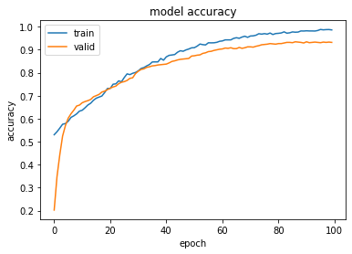

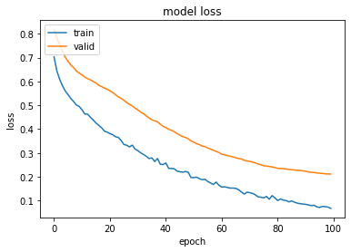

```
Loss is: 0.19914622604846954
Accuracy is: 0.9420889616012573
```

```python
def seed_everything(seed):
    np.random.seed(seed)
    os.environ['PYTHONHASHSEED'] = str(seed)
    tf.random.set_seed(seed)

N_FEATURES=len(x_train_df.columns)

seed_everything(1000)

model = model = tf.keras.Sequential([
        tf.keras.layers.Input(N_FEATURES),
        tf.keras.layers.BatchNormalization(),
        tf.keras.layers.Dropout(0.2),
        tfa.layers.WeightNormalization(tf.keras.layers.Dense(240, activation="relu")),
        tf.keras.layers.BatchNormalization(),
        tf.keras.layers.Dropout(0.2),
        tfa.layers.WeightNormalization(tf.keras.layers.Dense(1, activation="sigmoid"))
    ])

model.compile(optimizer=tf.keras.optimizers.Adam(learning_rate = 0.0001), loss='binary_crossentropy',
                  metrics=["accuracy"])

history=model.fit(x_train_df, y_train, epochs=100, batch_size=100, verbose=0,
                        validation_split=0.2, shuffle=True, class_weight=class_weight)

# summarize history for accuracy
plt.plot(history.history['accuracy'])
plt.plot(history.history['val_accuracy'])
plt.title('model accuracy')
plt.ylabel('accuracy')
plt.xlabel('epoch')
plt.legend(['train', 'valid'], loc='upper left')
plt.show()

# summarize history for loss
plt.plot(history.history['loss'])
plt.plot(history.history['val_loss'])
plt.title('model loss')
plt.ylabel('loss')
plt.xlabel('epoch')
plt.legend(['train', 'valid'], loc='upper left')
plt.show()

final_model_eval=model.evaluate(x_test_df, y_test, batch_size=100)
print("Loss is:",final_model_eval[0])
print("Accuracy is:",final_model_eval[1])
```

The following examples served as good metrics for loss curves showing underfitting/overfitting. Source: https://machinelearningmastery.com/learning-curves-for-diagnosing-machine-learning-model-performance/

## Underfitting:

"A plot of learning curves shows underfitting if:

-The training loss remains flat regardless of training.

-The training loss continues to decrease until the end of training."

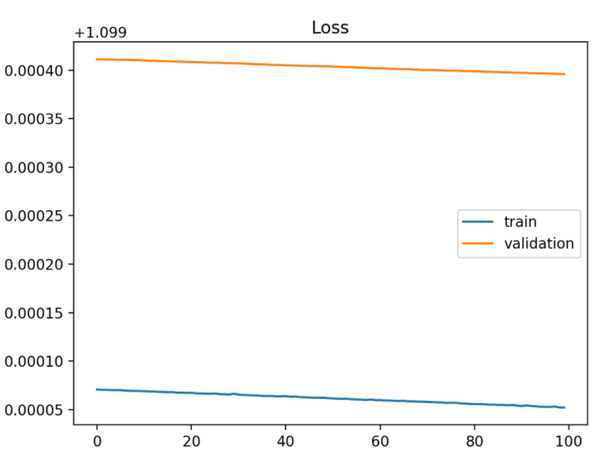

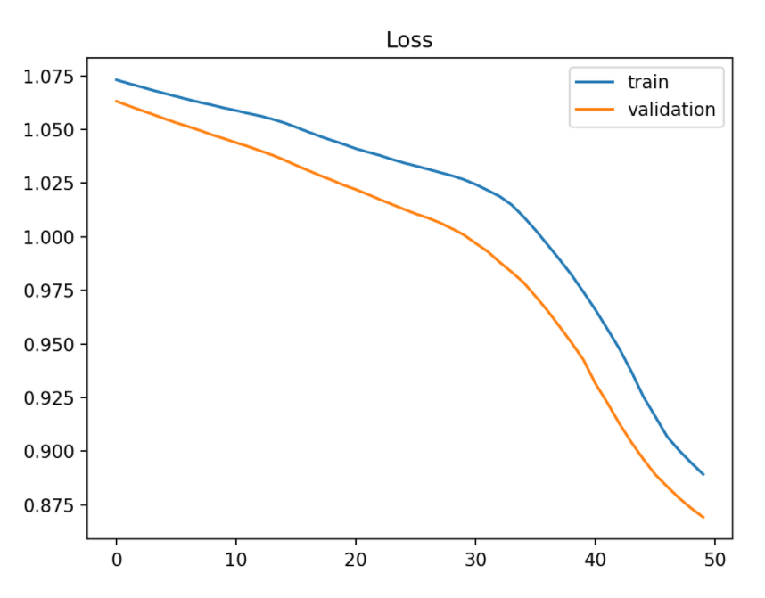

## Overfitting:

"A plot of learning curves shows overfitting if:

-The plot of training loss continues to decrease with experience.

-The plot of validation loss decreases to a point and begins increasing again."

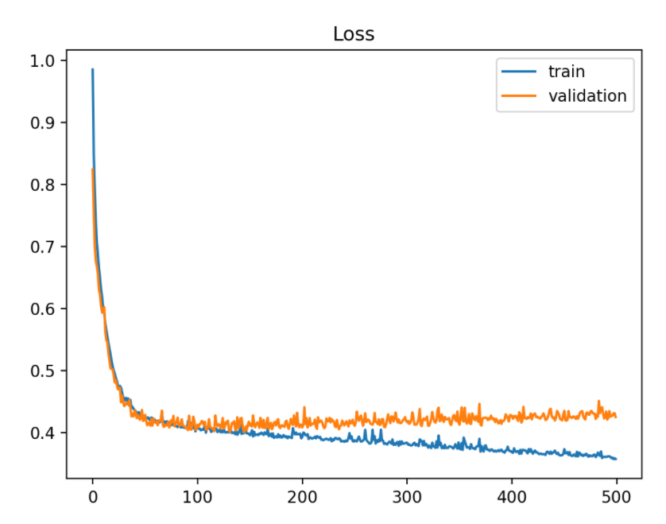

## Good fit

"A plot of learning curves shows a good fit if:

-The plot of training loss decreases to a point of stability.

-The plot of validation loss decreases to a point of stability and has a small gap with the training loss."

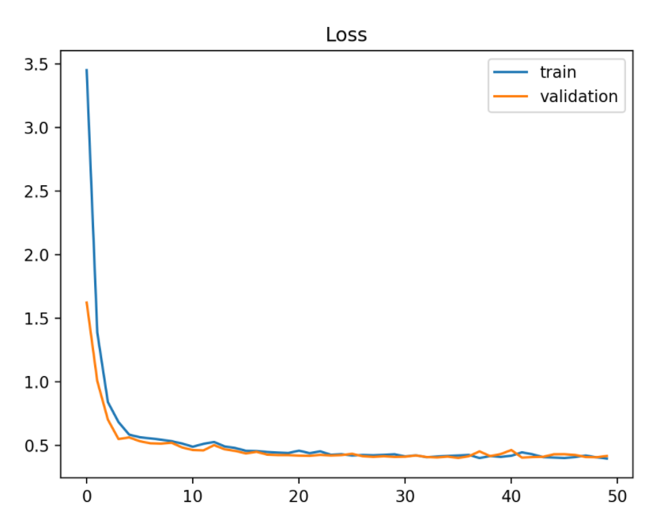

Note that the validation loss may be less than the training loss due to the dropout. This is of importance in my examples, particularly since some of my models have high dropout rates. One online source states, "If you are using dropout regularization layer in your network, it is reasonable that the validation error is smaller than training error. Because usually dropout is activated when training but deactivated when evaluating on the validation set." (Source: https://stats.stackexchange.com/questions/187335/validation-error-less-than-training-error#:~:text=One%20possibility%3A%20If%20you%20are,evaluating%20on%20the%20validation%20set). Additional online sources state the same.

## Evaluation of learning curve for original model

From the learning curve above (shown below for reference), the training curve appeared to still be decreasing, suggesting a possible underfit. I increased the learning rate to 0.001 to try to improve the fit.

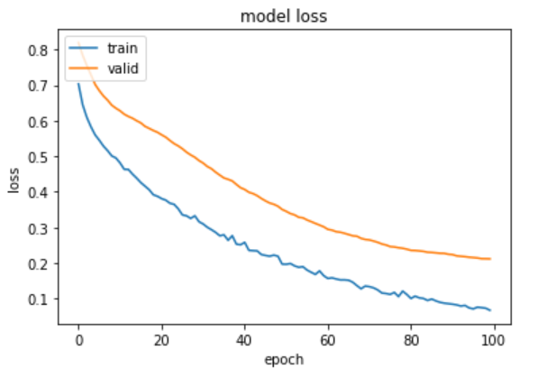

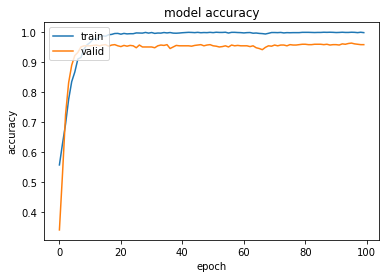

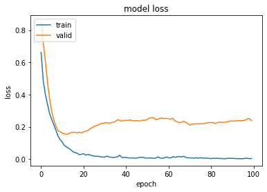

```
Loss is: 0.3373134434223175
Accuracy is: 0.9576008319854736
```

```python
#Learning rate adjusted to 0.001
seed_everything(1000)

model = model = tf.keras.Sequential([
        tf.keras.layers.Input(N_FEATURES),
        tf.keras.layers.BatchNormalization(),
        tf.keras.layers.Dropout(0.2),
        tfa.layers.WeightNormalization(tf.keras.layers.Dense(240, activation="relu")),
        tf.keras.layers.BatchNormalization(),
        tf.keras.layers.Dropout(0.2),
        tfa.layers.WeightNormalization(tf.keras.layers.Dense(1, activation="sigmoid"))
    ])

model.compile(optimizer=tf.keras.optimizers.Adam(learning_rate = 0.001), loss='binary_crossentropy',
                  metrics=["accuracy"])

history=model.fit(x_train_df, y_train, epochs=100, batch_size=100, verbose=0,
                        validation_split=0.2, shuffle=True, class_weight=class_weight)

# summarize history for accuracy
plt.plot(history.history['accuracy'])
plt.plot(history.history['val_accuracy'])
plt.title('model accuracy')
plt.ylabel('accuracy')
plt.xlabel('epoch')
plt.legend(['train', 'valid'], loc='upper left')
plt.show()

# summarize history for loss
plt.plot(history.history['loss'])
plt.plot(history.history['val_loss'])
plt.title('model loss')
plt.ylabel('loss')
plt.xlabel('epoch')
plt.legend(['train', 'valid'], loc='upper left')
plt.show()

final_model_eval=model.evaluate(x_test_df, y_test, batch_size=100)
print("Loss is:",final_model_eval[0])
print("Accuracy is:",final_model_eval[1])
```

The learning curve for this model showed overfitting, so I attempted to decrease the number of nodes to 200.

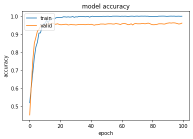

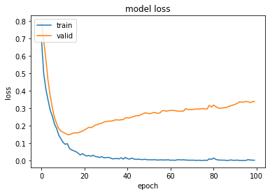

```
Loss is: 0.2789948582649231
Accuracy is: 0.9576008319854736
```

```python
#Nodes=200
seed_everything(1000)

model = model = tf.keras.Sequential([
        tf.keras.layers.Input(N_FEATURES),
        tf.keras.layers.BatchNormalization(),
        tf.keras.layers.Dropout(0.2),
        tfa.layers.WeightNormalization(tf.keras.layers.Dense(200, activation="relu")),
        tf.keras.layers.BatchNormalization(),
        tf.keras.layers.Dropout(0.2),
        tfa.layers.WeightNormalization(tf.keras.layers.Dense(1, activation="sigmoid"))
    ])

model.compile(optimizer=tf.keras.optimizers.Adam(learning_rate = 0.001), loss='binary_crossentropy',
                  metrics=["accuracy"])

history=model.fit(x_train_df, y_train, epochs=100, batch_size=100, verbose=0,
                        validation_split=0.2, shuffle=True, class_weight=class_weight)

# summarize history for accuracy
plt.plot(history.history['accuracy'])
plt.plot(history.history['val_accuracy'])
plt.title('model accuracy')
plt.ylabel('accuracy')
plt.xlabel('epoch')
plt.legend(['train', 'valid'], loc='upper left')
plt.show()

# summarize history for loss
plt.plot(history.history['loss'])
plt.plot(history.history['val_loss'])
plt.title('model loss')
plt.ylabel('loss')
plt.xlabel('epoch')
plt.legend(['train', 'valid'], loc='upper left')
plt.show()

final_model_eval=model.evaluate(x_test_df, y_test, batch_size=100)
print("Loss is:",final_model_eval[0])
print("Accuracy is:",final_model_eval[1])
```

The learning curve of this model still showed overfitting, so I decreased the number of nodes to 150.

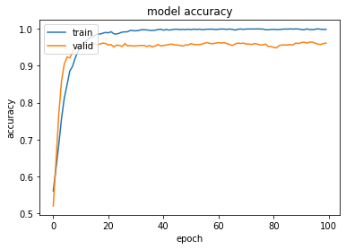

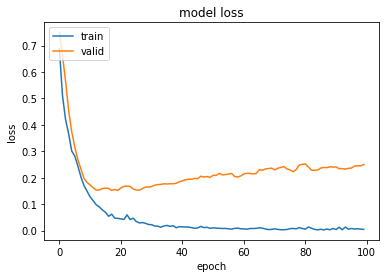

```
Loss is: 0.3039999306201935
Accuracy is: 0.9555325508117676
```

```python
#Nodes=150
seed_everything(1000)

model = model = tf.keras.Sequential([
        tf.keras.layers.Input(N_FEATURES),
        tf.keras.layers.BatchNormalization(),
        tf.keras.layers.Dropout(0.2),
        tfa.layers.WeightNormalization(tf.keras.layers.Dense(150, activation="relu")),
        tf.keras.layers.BatchNormalization(),
        tf.keras.layers.Dropout(0.2),
        tfa.layers.WeightNormalization(tf.keras.layers.Dense(1, activation="sigmoid"))
    ])

model.compile(optimizer=tf.keras.optimizers.Adam(learning_rate = 0.001), loss='binary_crossentropy',
                  metrics=["accuracy"])

history=model.fit(x_train_df, y_train, epochs=100, batch_size=100, verbose=0,
                        validation_split=0.2, shuffle=True, class_weight=class_weight)

# summarize history for accuracy
plt.plot(history.history['accuracy'])
plt.plot(history.history['val_accuracy'])
plt.title('model accuracy')
plt.ylabel('accuracy')
plt.xlabel('epoch')
plt.legend(['train', 'valid'], loc='upper left')
plt.show()

# summarize history for loss
plt.plot(history.history['loss'])
plt.plot(history.history['val_loss'])
plt.title('model loss')
plt.ylabel('loss')
plt.xlabel('epoch')
plt.legend(['train', 'valid'], loc='upper left')
plt.show()

final_model_eval=model.evaluate(x_test_df, y_test, batch_size=100)
print("Loss is:",final_model_eval[0])
print("Accuracy is:",final_model_eval[1])
```

The learning curve for this model still showed overfitting, so I decreased the number of nodes to 100.

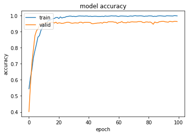

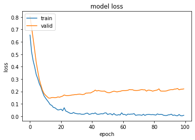

```
Loss is: 0.29598355293273926
Accuracy is: 0.9534643292427063
```

```python
#Nodes=100
seed_everything(1000)

model = model = tf.keras.Sequential([
        tf.keras.layers.Input(N_FEATURES),
        tf.keras.layers.BatchNormalization(),
        tf.keras.layers.Dropout(0.2),
        tfa.layers.WeightNormalization(tf.keras.layers.Dense(100, activation="relu")),
        tf.keras.layers.BatchNormalization(),
        tf.keras.layers.Dropout(0.2),
        tfa.layers.WeightNormalization(tf.keras.layers.Dense(1, activation="sigmoid"))
    ])

model.compile(optimizer=tf.keras.optimizers.Adam(learning_rate = 0.001), loss='binary_crossentropy',
                  metrics=["accuracy"])

history=model.fit(x_train_df, y_train, epochs=100, batch_size=100, verbose=0,
                        validation_split=0.2, shuffle=True, class_weight=class_weight)

# summarize history for accuracy
plt.plot(history.history['accuracy'])
plt.plot(history.history['val_accuracy'])
plt.title('model accuracy')
plt.ylabel('accuracy')
plt.xlabel('epoch')
plt.legend(['train', 'valid'], loc='upper left')
plt.show()

# summarize history for loss
plt.plot(history.history['loss'])
plt.plot(history.history['val_loss'])
plt.title('model loss')
plt.ylabel('loss')
plt.xlabel('epoch')
plt.legend(['train', 'valid'], loc='upper left')
plt.show()

final_model_eval=model.evaluate(x_test_df, y_test, batch_size=100)
print("Loss is:",final_model_eval[0])
print("Accuracy is:",final_model_eval[1])
```

The learning curve for this model still showed overfitting, so I decreased the number of nodes to 50.

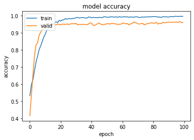

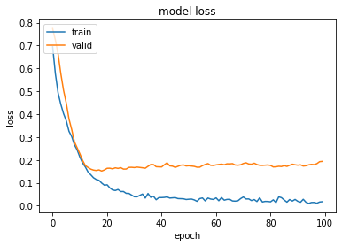

```
Loss is: 0.2673291862010956
Accuracy is: 0.9524301886558533
```

```python
#Nodes=50
seed_everything(1000)

model = model = tf.keras.Sequential([
        tf.keras.layers.Input(N_FEATURES),
        tf.keras.layers.BatchNormalization(),
        tf.keras.layers.Dropout(0.2),
        tfa.layers.WeightNormalization(tf.keras.layers.Dense(50, activation="relu")),
        tf.keras.layers.BatchNormalization(),
        tf.keras.layers.Dropout(0.2),
        tfa.layers.WeightNormalization(tf.keras.layers.Dense(1, activation="sigmoid"))
    ])

model.compile(optimizer=tf.keras.optimizers.Adam(learning_rate = 0.001), loss='binary_crossentropy',
                  metrics=["accuracy"])

history=model.fit(x_train_df, y_train, epochs=100, batch_size=100, verbose=0,
                        validation_split=0.2, shuffle=True, class_weight=class_weight)

# summarize history for accuracy
plt.plot(history.history['accuracy'])
plt.plot(history.history['val_accuracy'])
plt.title('model accuracy')
plt.ylabel('accuracy')
plt.xlabel('epoch')
plt.legend(['train', 'valid'], loc='upper left')
plt.show()

# summarize history for loss
plt.plot(history.history['loss'])
plt.plot(history.history['val_loss'])
plt.title('model loss')
plt.ylabel('loss')
plt.xlabel('epoch')
plt.legend(['train', 'valid'], loc='upper left')
plt.show()

final_model_eval=model.evaluate(x_test_df, y_test, batch_size=100)
print("Loss is:",final_model_eval[0])
print("Accuracy is:",final_model_eval[1])
```

The learning curve for this model still showed overfitting, so I decreased the number of nodes to 25.

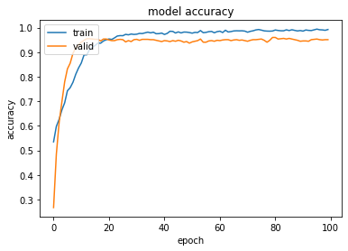

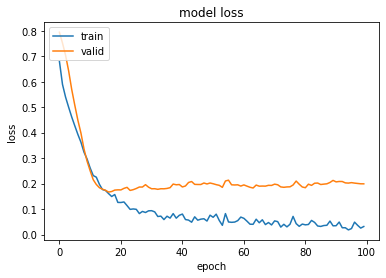

```
Loss is: 0.24240157008171082
Accuracy is: 0.949327826499939
```

```python
#Nodes=25
seed_everything(1000)

model = model = tf.keras.Sequential([
        tf.keras.layers.Input(N_FEATURES),
        tf.keras.layers.BatchNormalization(),
        tf.keras.layers.Dropout(0.2),
        tfa.layers.WeightNormalization(tf.keras.layers.Dense(25, activation="relu")),
        tf.keras.layers.BatchNormalization(),
        tf.keras.layers.Dropout(0.2),
        tfa.layers.WeightNormalization(tf.keras.layers.Dense(1, activation="sigmoid"))
    ])

model.compile(optimizer=tf.keras.optimizers.Adam(learning_rate = 0.001), loss='binary_crossentropy',
                  metrics=["accuracy"])

history=model.fit(x_train_df, y_train, epochs=100, batch_size=100, verbose=0,
                        validation_split=0.2, shuffle=True, class_weight=class_weight)

# summarize history for accuracy
plt.plot(history.history['accuracy'])
plt.plot(history.history['val_accuracy'])
plt.title('model accuracy')
plt.ylabel('accuracy')
plt.xlabel('epoch')
plt.legend(['train', 'valid'], loc='upper left')
plt.show()

# summarize history for loss
plt.plot(history.history['loss'])
plt.plot(history.history['val_loss'])
plt.title('model loss')
plt.ylabel('loss')
plt.xlabel('epoch')
plt.legend(['train', 'valid'], loc='upper left')
plt.show()

final_model_eval=model.evaluate(x_test_df, y_test, batch_size=100)
print("Loss is:",final_model_eval[0])
print("Accuracy is:",final_model_eval[1])
```

The learning curve for this model still showed overfitting, so I decreased the number of nodes to 10.

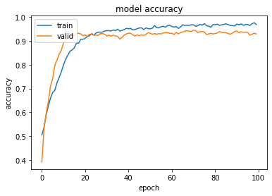

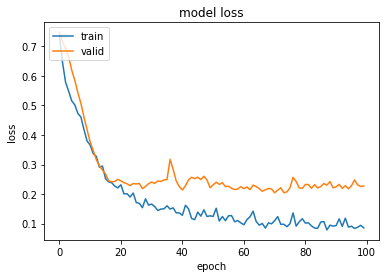

```
Loss is: 0.27393853664398193
Accuracy is: 0.9348500370979309
```

```python
#Nodes=10
seed_everything(1000)

model = model = tf.keras.Sequential([
        tf.keras.layers.Input(N_FEATURES),
        tf.keras.layers.BatchNormalization(),
        tf.keras.layers.Dropout(0.2),
        tfa.layers.WeightNormalization(tf.keras.layers.Dense(10, activation="relu")),
        tf.keras.layers.BatchNormalization(),
        tf.keras.layers.Dropout(0.2),
        tfa.layers.WeightNormalization(tf.keras.layers.Dense(1, activation="sigmoid"))
    ])

model.compile(optimizer=tf.keras.optimizers.Adam(learning_rate = 0.001), loss='binary_crossentropy',
                  metrics=["accuracy"])

history=model.fit(x_train_df, y_train, epochs=100, batch_size=100, verbose=0,
                        validation_split=0.2, shuffle=True, class_weight=class_weight)

# summarize history for accuracy
plt.plot(history.history['accuracy'])
plt.plot(history.history['val_accuracy'])
plt.title('model accuracy')
plt.ylabel('accuracy')
plt.xlabel('epoch')
plt.legend(['train', 'valid'], loc='upper left')
plt.show()

# summarize history for loss
plt.plot(history.history['loss'])
plt.plot(history.history['val_loss'])
plt.title('model loss')
plt.ylabel('loss')
plt.xlabel('epoch')
plt.legend(['train', 'valid'], loc='upper left')
plt.show()

final_model_eval=model.evaluate(x_test_df, y_test, batch_size=100)
print("Loss is:",final_model_eval[0])
print("Accuracy is:",final_model_eval[1])
```

The learning curve for this simple model seemed okay, so I predicted values using this model.

```python
nn_predictions=model.predict(x_test_df)
```

```python
def nn_predict(threshold):
    predictions_df1=pd.DataFrame(nn_predictions)
    predictions_df=predictions_df1.rename(columns={0: 'probability'})
    #print(predictions_df)
    predictions_df['suicide_attempt'] = np.nan
    predictions_df['suicide_attempt'] = np.where(predictions_df['probability']>=threshold, 1, 0)
    final_predictions=predictions_df['suicide_attempt']

    c=confusion_matrix(y_test, predictions_df['suicide_attempt'])
    recall=c[1,1] / (c[1,1] + c[1,0])
    precision=c[1,1]/(c[0,1]+c[1,1])
    print('Confusion matrix when threshold=',threshold,'\n',c)
    print('Sensitivity/recall when threshold =',threshold, ':', recall)
    print('Specificity when threshold =',threshold, ':', c[0, 0] / (c[0, 1] + c[0, 0]))
    print('Precision when threshold =',threshold,':',precision)
    print('F1 Score when threshold =',threshold,':',(2*precision*recall)/(precision+recall))
    print('Accuracy when threshold =',threshold,':',(c[0,0]+c[1,1])/(c[0,0]+c[0,1]+c[1,0]+c[1,1]))
    print('\n')
    return

nn_predict(0.50)
nn_predict(0.40)
nn_predict(0.35)
nn_predict(0.30)
nn_predict(0.20)
nn_predict(0.10)
nn_predict(0.05)
nn_predict(0.01)
nn_predict(0.005)
nn_predict(0.004)
nn_predict(0.003)
nn_predict(0.002)
```

```
Confusion matrix when threshold= 0.5
 [[896  33]
 [ 30   8]]
Sensitivity/recall when threshold = 0.5 : 0.21052631578947367
Specificity when threshold = 0.5 : 0.9644779332615716
Precision when threshold = 0.5 : 0.1951219512195122
F1 Score when threshold = 0.5 : 0.20253164556962025
Accuracy when threshold = 0.5 : 0.9348500517063082


Confusion matrix when threshold= 0.4
 [[882  47]
 [ 29   9]]
Sensitivity/recall when threshold = 0.4 : 0.23684210526315788
Specificity when threshold = 0.4 : 0.9494079655543596
Precision when threshold = 0.4 : 0.16071428571428573
F1 Score when threshold = 0.4 : 0.19148936170212766
Accuracy when threshold = 0.4 : 0.921406411582213


Confusion matrix when threshold= 0.35
 [[879  50]
 [ 29   9]]
Sensitivity/recall when threshold = 0.35 : 0.23684210526315788
Specificity when threshold = 0.35 : 0.946178686759957
Precision when threshold = 0.35 : 0.15254237288135594
F1 Score when threshold = 0.35 : 0.18556701030927836
Accuracy when threshold = 0.35 : 0.9183040330920372


Confusion matrix when threshold= 0.3
 [[876  53]
 [ 28  10]]
Sensitivity/recall when threshold = 0.3 : 0.2631578947368421
Specificity when threshold = 0.3 : 0.9429494079655544
Precision when threshold = 0.3 : 0.15873015873015872
F1 Score when threshold = 0.3 : 0.19801980198019803
Accuracy when threshold = 0.3 : 0.9162357807652534


```

[output cut: 63 more lines]

```
Sensitivity/recall when threshold = 0.003 : 0.8947368421052632
Specificity when threshold = 0.003 : 0.35414424111948334
Precision when threshold = 0.003 : 0.05362776025236593
F1 Score when threshold = 0.003 : 0.10119047619047619
Accuracy when threshold = 0.003 : 0.375387797311272


Confusion matrix when threshold= 0.002
 [[260 669]
 [  3  35]]
Sensitivity/recall when threshold = 0.002 : 0.9210526315789473
Specificity when threshold = 0.002 : 0.2798708288482239
Precision when threshold = 0.002 : 0.04971590909090909
F1 Score when threshold = 0.002 : 0.09433962264150943
Accuracy when threshold = 0.002 : 0.3050672182006205
```

As with the logistic regression models, I examined specificity when sensitivity was equal to 0.92. Specificity was low when sensitivity was equal to 0.92 (0.28), so I attempted to increase the number of nodes back to 25, but with a dropout rate of 0.3.

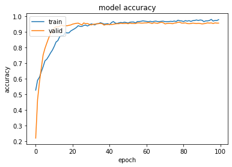

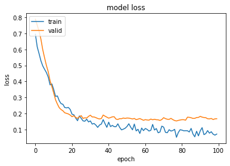

```
Loss is: 0.19256262481212616
Accuracy is: 0.9544984698295593
```

```python
#Nodes=25; Dropout Rate=0.3
seed_everything(1000)

model = model = tf.keras.Sequential([
        tf.keras.layers.Input(N_FEATURES),
        tf.keras.layers.BatchNormalization(),
        tf.keras.layers.Dropout(0.3),
        tfa.layers.WeightNormalization(tf.keras.layers.Dense(25, activation="relu")),
        tf.keras.layers.BatchNormalization(),
        tf.keras.layers.Dropout(0.3),
        tfa.layers.WeightNormalization(tf.keras.layers.Dense(1, activation="sigmoid"))
    ])

model.compile(optimizer=tf.keras.optimizers.Adam(learning_rate = 0.001), loss='binary_crossentropy',
                  metrics=["accuracy"])

history=model.fit(x_train_df, y_train, epochs=100, batch_size=100, verbose=0,
                        validation_split=0.2, shuffle=True, class_weight=class_weight)

# summarize history for accuracy
plt.plot(history.history['accuracy'])
plt.plot(history.history['val_accuracy'])
plt.title('model accuracy')
plt.ylabel('accuracy')
plt.xlabel('epoch')
plt.legend(['train', 'valid'], loc='upper left')
plt.show()

# summarize history for loss
plt.plot(history.history['loss'])
plt.plot(history.history['val_loss'])
plt.title('model loss')
plt.ylabel('loss')
plt.xlabel('epoch')
plt.legend(['train', 'valid'], loc='upper left')
plt.show()

final_model_eval=model.evaluate(x_test_df, y_test, batch_size=100)
print("Loss is:",final_model_eval[0])
print("Accuracy is:",final_model_eval[1])
```

The learning curve for this model seemed okay, so I predicted values using this model.

```python
nn_predictions=model.predict(x_test_df)
```

```python
nn_predict(0.50)
nn_predict(0.40)
nn_predict(0.35)
nn_predict(0.30)
nn_predict(0.20)
nn_predict(0.10)
nn_predict(0.05)
nn_predict(0.01)
nn_predict(0.005)
nn_predict(0.001)
```

```
Confusion matrix when threshold= 0.5
 [[917  12]
 [ 32   6]]
Sensitivity/recall when threshold = 0.5 : 0.15789473684210525
Specificity when threshold = 0.5 : 0.9870828848223897
Precision when threshold = 0.5 : 0.3333333333333333
F1 Score when threshold = 0.5 : 0.21428571428571427
Accuracy when threshold = 0.5 : 0.954498448810755


Confusion matrix when threshold= 0.4
 [[915  14]
 [ 30   8]]
Sensitivity/recall when threshold = 0.4 : 0.21052631578947367
Specificity when threshold = 0.4 : 0.984930032292788
Precision when threshold = 0.4 : 0.36363636363636365
F1 Score when threshold = 0.4 : 0.26666666666666666
Accuracy when threshold = 0.4 : 0.954498448810755


Confusion matrix when threshold= 0.35
 [[915  14]
 [ 29   9]]
Sensitivity/recall when threshold = 0.35 : 0.23684210526315788
Specificity when threshold = 0.35 : 0.984930032292788
Precision when threshold = 0.35 : 0.391304347826087
F1 Score when threshold = 0.35 : 0.2950819672131147
Accuracy when threshold = 0.35 : 0.9555325749741469


Confusion matrix when threshold= 0.3
 [[912  17]
 [ 27  11]]
Sensitivity/recall when threshold = 0.3 : 0.2894736842105263
Specificity when threshold = 0.3 : 0.9817007534983854
Precision when threshold = 0.3 : 0.39285714285714285
F1 Score when threshold = 0.3 : 0.33333333333333337
Accuracy when threshold = 0.3 : 0.954498448810755


```

[output cut: 43 more lines]

```
Sensitivity/recall when threshold = 0.005 : 0.8421052631578947
Specificity when threshold = 0.005 : 0.5672766415500539
Precision when threshold = 0.005 : 0.07373271889400922
F1 Score when threshold = 0.005 : 0.13559322033898305
Accuracy when threshold = 0.005 : 0.578076525336091


Confusion matrix when threshold= 0.001
 [[246 683]
 [  3  35]]
Sensitivity/recall when threshold = 0.001 : 0.9210526315789473
Specificity when threshold = 0.001 : 0.26480086114101187
Precision when threshold = 0.001 : 0.04874651810584958
F1 Score when threshold = 0.001 : 0.09259259259259259
Accuracy when threshold = 0.001 : 0.2905894519131334
```

I again examined specificity when sensitivity was equal to 0.92. Specificity was essentially the same when sensitivity was equal to 0.92 (0.26) as in the last model that I tried (0.28), and was still low, so I attempted to increase the number of nodes to 50 with a dropout rate of 0.3.

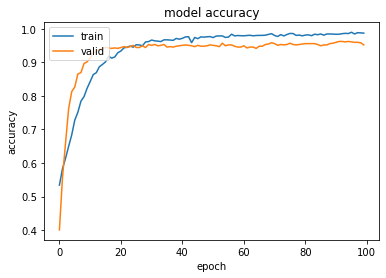

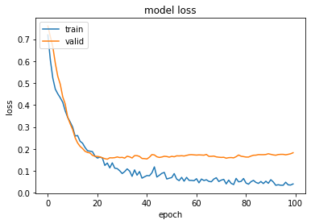

```
Loss is: 0.2313338965177536
Accuracy is: 0.9534643292427063
```

```python
#Nodes=50; Dropout Rate=0.3
seed_everything(1000)

model = model = tf.keras.Sequential([
        tf.keras.layers.Input(N_FEATURES),
        tf.keras.layers.BatchNormalization(),
        tf.keras.layers.Dropout(0.3),
        tfa.layers.WeightNormalization(tf.keras.layers.Dense(50, activation="relu")),
        tf.keras.layers.BatchNormalization(),
        tf.keras.layers.Dropout(0.3),
        tfa.layers.WeightNormalization(tf.keras.layers.Dense(1, activation="sigmoid"))
    ])

model.compile(optimizer=tf.keras.optimizers.Adam(learning_rate = 0.001), loss='binary_crossentropy',
                  metrics=["accuracy"])

history=model.fit(x_train_df, y_train, epochs=100, batch_size=100, verbose=0,
                        validation_split=0.2, shuffle=True, class_weight=class_weight)

# summarize history for accuracy
plt.plot(history.history['accuracy'])
plt.plot(history.history['val_accuracy'])
plt.title('model accuracy')
plt.ylabel('accuracy')
plt.xlabel('epoch')
plt.legend(['train', 'valid'], loc='upper left')
plt.show()

# summarize history for loss
plt.plot(history.history['loss'])
plt.plot(history.history['val_loss'])
plt.title('model loss')
plt.ylabel('loss')
plt.xlabel('epoch')
plt.legend(['train', 'valid'], loc='upper left')
plt.show()

final_model_eval=model.evaluate(x_test_df, y_test, batch_size=100)
print("Loss is:",final_model_eval[0])
print("Accuracy is:",final_model_eval[1])
```

The learning curve for this model shows overfitting, so I changed the dropout rate to 0.4.

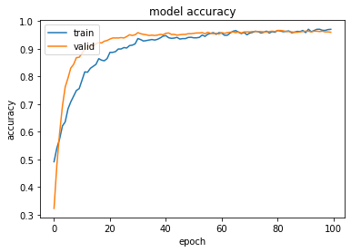

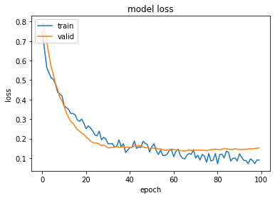

```
Loss is: 0.18418902158737183
Accuracy is: 0.9565666913986206
```

```python
#Nodes=50; Dropout Rate=0.4
seed_everything(1000)

model = model = tf.keras.Sequential([
        tf.keras.layers.Input(N_FEATURES),
        tf.keras.layers.BatchNormalization(),
        tf.keras.layers.Dropout(0.4),
        tfa.layers.WeightNormalization(tf.keras.layers.Dense(50, activation="relu")),
        tf.keras.layers.BatchNormalization(),
        tf.keras.layers.Dropout(0.4),
        tfa.layers.WeightNormalization(tf.keras.layers.Dense(1, activation="sigmoid"))
    ])

model.compile(optimizer=tf.keras.optimizers.Adam(learning_rate = 0.001), loss='binary_crossentropy',
                  metrics=["accuracy"])

history=model.fit(x_train_df, y_train, epochs=100, batch_size=100, verbose=0,
                        validation_split=0.2, shuffle=True, class_weight=class_weight)

# summarize history for accuracy
plt.plot(history.history['accuracy'])
plt.plot(history.history['val_accuracy'])
plt.title('model accuracy')
plt.ylabel('accuracy')
plt.xlabel('epoch')
plt.legend(['train', 'valid'], loc='upper left')
plt.show()

# summarize history for loss
plt.plot(history.history['loss'])
plt.plot(history.history['val_loss'])
plt.title('model loss')
plt.ylabel('loss')
plt.xlabel('epoch')
plt.legend(['train', 'valid'], loc='upper left')
plt.show()

final_model_eval=model.evaluate(x_test_df, y_test, batch_size=100)
print("Loss is:",final_model_eval[0])
print("Accuracy is:",final_model_eval[1])
```

I repeated the model limited to 50 epochs.

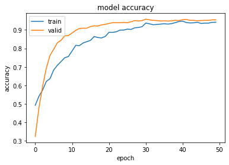

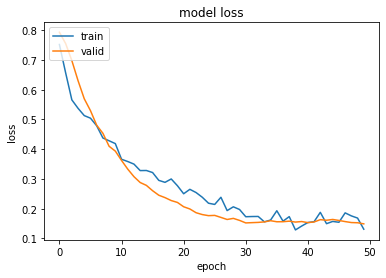

```
Loss is: 0.17962107062339783
Accuracy is: 0.9472595453262329
```

```python
#Nodes=50; Dropout Rate=0.4; Epochs=50
seed_everything(1000)

model = model = tf.keras.Sequential([
        tf.keras.layers.Input(N_FEATURES),
        tf.keras.layers.BatchNormalization(),
        tf.keras.layers.Dropout(0.4),
        tfa.layers.WeightNormalization(tf.keras.layers.Dense(50, activation="relu")),
        tf.keras.layers.BatchNormalization(),
        tf.keras.layers.Dropout(0.4),
        tfa.layers.WeightNormalization(tf.keras.layers.Dense(1, activation="sigmoid"))
    ])

model.compile(optimizer=tf.keras.optimizers.Adam(learning_rate = 0.001), loss='binary_crossentropy',
                  metrics=["accuracy"])

history=model.fit(x_train_df, y_train, epochs=50, batch_size=100, verbose=0,
                        validation_split=0.2, shuffle=True, class_weight=class_weight)

# summarize history for accuracy
plt.plot(history.history['accuracy'])
plt.plot(history.history['val_accuracy'])
plt.title('model accuracy')
plt.ylabel('accuracy')
plt.xlabel('epoch')
plt.legend(['train', 'valid'], loc='upper left')
plt.show()

# summarize history for loss
plt.plot(history.history['loss'])
plt.plot(history.history['val_loss'])
plt.title('model loss')
plt.ylabel('loss')
plt.xlabel('epoch')
plt.legend(['train', 'valid'], loc='upper left')
plt.show()

final_model_eval=model.evaluate(x_test_df, y_test, batch_size=100)
print("Loss is:",final_model_eval[0])
print("Accuracy is:",final_model_eval[1])
```

The learning curve for this simple model seemed okay, so I predicted values using this model.

```python
nn_predictions=model.predict(x_test_df)
```

```python
nn_predict(0.50)
nn_predict(0.40)
nn_predict(0.35)
nn_predict(0.30)
nn_predict(0.20)
nn_predict(0.10)
nn_predict(0.05)
nn_predict(0.01)
nn_predict(0.009)
nn_predict(0.008)
```

```
Confusion matrix when threshold= 0.5
 [[912  17]
 [ 34   4]]
Sensitivity/recall when threshold = 0.5 : 0.10526315789473684
Specificity when threshold = 0.5 : 0.9817007534983854
Precision when threshold = 0.5 : 0.19047619047619047
F1 Score when threshold = 0.5 : 0.13559322033898305
Accuracy when threshold = 0.5 : 0.9472595656670114


Confusion matrix when threshold= 0.4
 [[904  25]
 [ 32   6]]
Sensitivity/recall when threshold = 0.4 : 0.15789473684210525
Specificity when threshold = 0.4 : 0.9730893433799784
Precision when threshold = 0.4 : 0.1935483870967742
F1 Score when threshold = 0.4 : 0.17391304347826086
Accuracy when threshold = 0.4 : 0.9410548086866598


Confusion matrix when threshold= 0.35
 [[897  32]
 [ 32   6]]
Sensitivity/recall when threshold = 0.35 : 0.15789473684210525
Specificity when threshold = 0.35 : 0.9655543595263725
Precision when threshold = 0.35 : 0.15789473684210525
F1 Score when threshold = 0.35 : 0.15789473684210525
Accuracy when threshold = 0.35 : 0.9338159255429163


Confusion matrix when threshold= 0.3
 [[893  36]
 [ 32   6]]
Sensitivity/recall when threshold = 0.3 : 0.15789473684210525
Specificity when threshold = 0.3 : 0.961248654467169
Precision when threshold = 0.3 : 0.14285714285714285
F1 Score when threshold = 0.3 : 0.15
Accuracy when threshold = 0.3 : 0.9296794208893485


```

[output cut: 43 more lines]

```
Sensitivity/recall when threshold = 0.009 : 0.8947368421052632
Specificity when threshold = 0.009 : 0.37782561894510225
Precision when threshold = 0.009 : 0.05555555555555555
F1 Score when threshold = 0.009 : 0.10461538461538461
Accuracy when threshold = 0.009 : 0.3981385729058945


Confusion matrix when threshold= 0.008
 [[326 603]
 [  3  35]]
Sensitivity/recall when threshold = 0.008 : 0.9210526315789473
Specificity when threshold = 0.008 : 0.35091496232508074
Precision when threshold = 0.008 : 0.054858934169279
F1 Score when threshold = 0.008 : 0.10355029585798817
Accuracy when threshold = 0.008 : 0.3733195449844881
```

I again examined specificity when sensitivity was equal to 0.92. Specificity was higher when sensitivity was equal to 0.92 (0.35) than the highest sensitivity in previous models that I had tried (0.28), so I attempted to increase the number of nodes to 100 with a dropout rate of 0.4.

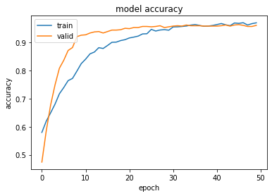

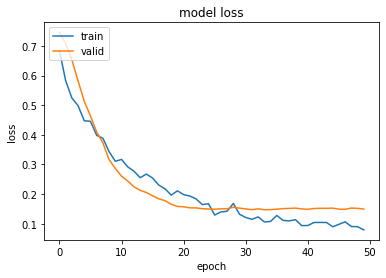

```
Loss is: 0.1926761120557785
Accuracy is: 0.9555325508117676
```

```python
#Nodes=100; Dropout Rate=0.4; Epochs=50
seed_everything(1000)

model = model = tf.keras.Sequential([
        tf.keras.layers.Input(N_FEATURES),
        tf.keras.layers.BatchNormalization(),
        tf.keras.layers.Dropout(0.4),
        tfa.layers.WeightNormalization(tf.keras.layers.Dense(100, activation="relu")),
        tf.keras.layers.BatchNormalization(),
        tf.keras.layers.Dropout(0.4),
        tfa.layers.WeightNormalization(tf.keras.layers.Dense(1, activation="sigmoid"))
    ])

model.compile(optimizer=tf.keras.optimizers.Adam(learning_rate = 0.001), loss='binary_crossentropy',
                  metrics=["accuracy"])

history=model.fit(x_train_df, y_train, epochs=50, batch_size=100, verbose=0,
                        validation_split=0.2, shuffle=True, class_weight=class_weight)

# summarize history for accuracy
plt.plot(history.history['accuracy'])
plt.plot(history.history['val_accuracy'])
plt.title('model accuracy')
plt.ylabel('accuracy')
plt.xlabel('epoch')
plt.legend(['train', 'valid'], loc='upper left')
plt.show()

# summarize history for loss
plt.plot(history.history['loss'])
plt.plot(history.history['val_loss'])
plt.title('model loss')
plt.ylabel('loss')
plt.xlabel('epoch')
plt.legend(['train', 'valid'], loc='upper left')
plt.show()

final_model_eval=model.evaluate(x_test_df, y_test, batch_size=100)
print("Loss is:",final_model_eval[0])
print("Accuracy is:",final_model_eval[1])
```

The learning curve for the training dataset kept decreasing, suggesting underfitting, so I attempted to increase the number of epochs back to 100.

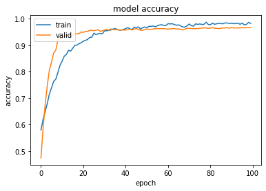

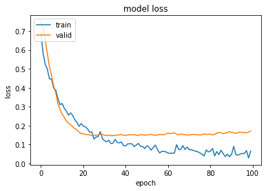

```
Loss is: 0.2132689207792282
Accuracy is: 0.9555325508117676
```

```python
#Nodes=100; Dropout Rate=0.4; Epochs=100
seed_everything(1000)

model = model = tf.keras.Sequential([
        tf.keras.layers.Input(N_FEATURES),
        tf.keras.layers.BatchNormalization(),
        tf.keras.layers.Dropout(0.4),
        tfa.layers.WeightNormalization(tf.keras.layers.Dense(100, activation="relu")),
        tf.keras.layers.BatchNormalization(),
        tf.keras.layers.Dropout(0.4),
        tfa.layers.WeightNormalization(tf.keras.layers.Dense(1, activation="sigmoid"))
    ])

model.compile(optimizer=tf.keras.optimizers.Adam(learning_rate = 0.001), loss='binary_crossentropy',
                  metrics=["accuracy"])

history=model.fit(x_train_df, y_train, epochs=100, batch_size=100, verbose=0,
                        validation_split=0.2, shuffle=True, class_weight=class_weight)

# summarize history for accuracy
plt.plot(history.history['accuracy'])
plt.plot(history.history['val_accuracy'])
plt.title('model accuracy')
plt.ylabel('accuracy')
plt.xlabel('epoch')
plt.legend(['train', 'valid'], loc='upper left')
plt.show()

# summarize history for loss
plt.plot(history.history['loss'])
plt.plot(history.history['val_loss'])
plt.title('model loss')
plt.ylabel('loss')
plt.xlabel('epoch')
plt.legend(['train', 'valid'], loc='upper left')
plt.show()

final_model_eval=model.evaluate(x_test_df, y_test, batch_size=100)
print("Loss is:",final_model_eval[0])
print("Accuracy is:",final_model_eval[1])
```

The learning curve for the model now showed overfitting. I tried to decrease the batch size to 50 at 100 epochs.

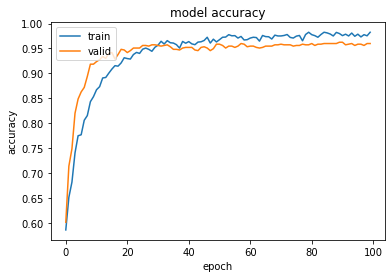

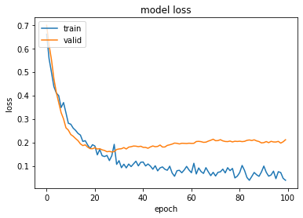

```
Loss is: 0.2586914896965027
Accuracy is: 0.9555325508117676
```

```python
#Nodes=100; Dropout Rate=0.4; Epochs=100; Batch Size=50
seed_everything(1000)

model = model = tf.keras.Sequential([
        tf.keras.layers.Input(N_FEATURES),
        tf.keras.layers.BatchNormalization(),
        tf.keras.layers.Dropout(0.4),
        tfa.layers.WeightNormalization(tf.keras.layers.Dense(100, activation="relu")),
        tf.keras.layers.BatchNormalization(),
        tf.keras.layers.Dropout(0.4),
        tfa.layers.WeightNormalization(tf.keras.layers.Dense(1, activation="sigmoid"))
    ])

model.compile(optimizer=tf.keras.optimizers.Adam(learning_rate = 0.001), loss='binary_crossentropy',
                  metrics=["accuracy"])

history=model.fit(x_train_df, y_train, epochs=100, batch_size=50, verbose=0,
                        validation_split=0.2, shuffle=True, class_weight=class_weight)

# summarize history for accuracy
plt.plot(history.history['accuracy'])
plt.plot(history.history['val_accuracy'])
plt.title('model accuracy')
plt.ylabel('accuracy')
plt.xlabel('epoch')
plt.legend(['train', 'valid'], loc='upper left')
plt.show()

# summarize history for loss
plt.plot(history.history['loss'])
plt.plot(history.history['val_loss'])
plt.title('model loss')
plt.ylabel('loss')
plt.xlabel('epoch')
plt.legend(['train', 'valid'], loc='upper left')
plt.show()

final_model_eval=model.evaluate(x_test_df, y_test, batch_size=50)
print("Loss is:",final_model_eval[0])
print("Accuracy is:",final_model_eval[1])
```

The learning curve for the model still shows overfitting. I tried to increase the dropout rate to 0.5.

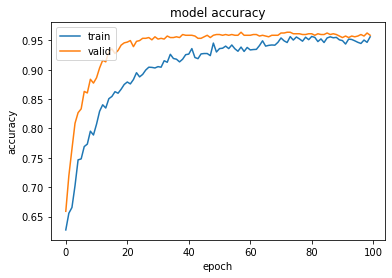

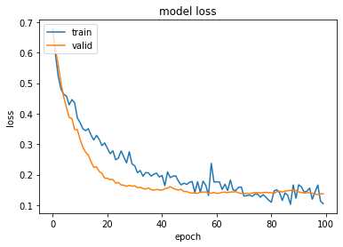

```
Loss is: 0.1868666559457779
Accuracy is: 0.9555325508117676
```

```python
#Nodes=100; Dropout Rate=0.5; Epochs=100; Batch Size=50
seed_everything(1000)

model = model = tf.keras.Sequential([
        tf.keras.layers.Input(N_FEATURES),
        tf.keras.layers.BatchNormalization(),
        tf.keras.layers.Dropout(0.5),
        tfa.layers.WeightNormalization(tf.keras.layers.Dense(100, activation="relu")),
        tf.keras.layers.BatchNormalization(),
        tf.keras.layers.Dropout(0.5),
        tfa.layers.WeightNormalization(tf.keras.layers.Dense(1, activation="sigmoid"))
    ])

model.compile(optimizer=tf.keras.optimizers.Adam(learning_rate = 0.001), loss='binary_crossentropy',
                  metrics=["accuracy"])

history=model.fit(x_train_df, y_train, epochs=100, batch_size=50, verbose=0,
                        validation_split=0.2, shuffle=True, class_weight=class_weight)

# summarize history for accuracy
plt.plot(history.history['accuracy'])
plt.plot(history.history['val_accuracy'])
plt.title('model accuracy')
plt.ylabel('accuracy')
plt.xlabel('epoch')
plt.legend(['train', 'valid'], loc='upper left')
plt.show()

# summarize history for loss
plt.plot(history.history['loss'])
plt.plot(history.history['val_loss'])
plt.title('model loss')
plt.ylabel('loss')
plt.xlabel('epoch')
plt.legend(['train', 'valid'], loc='upper left')
plt.show()

final_model_eval=model.evaluate(x_test_df, y_test, batch_size=50)
print("Loss is:",final_model_eval[0])
print("Accuracy is:",final_model_eval[1])
```

The learning curve for this model seemed okay, so I predicted values using this model.

```python
nn_predictions=model.predict(x_test_df)
```

```python
nn_predict(0.50)
nn_predict(0.40)
nn_predict(0.35)
nn_predict(0.30)
nn_predict(0.20)
nn_predict(0.10)
nn_predict(0.05)
nn_predict(0.01)
nn_predict(0.009)
nn_predict(0.008)
nn_predict(0.007)
nn_predict(0.006)
nn_predict(0.005)
```

```
Confusion matrix when threshold= 0.5
 [[923   6]
 [ 37   1]]
Sensitivity/recall when threshold = 0.5 : 0.02631578947368421
Specificity when threshold = 0.5 : 0.9935414424111948
Precision when threshold = 0.5 : 0.14285714285714285
F1 Score when threshold = 0.5 : 0.044444444444444446
Accuracy when threshold = 0.5 : 0.9555325749741469


Confusion matrix when threshold= 0.4
 [[923   6]
 [ 37   1]]
Sensitivity/recall when threshold = 0.4 : 0.02631578947368421
Specificity when threshold = 0.4 : 0.9935414424111948
Precision when threshold = 0.4 : 0.14285714285714285
F1 Score when threshold = 0.4 : 0.044444444444444446
Accuracy when threshold = 0.4 : 0.9555325749741469


Confusion matrix when threshold= 0.35
 [[920   9]
 [ 36   2]]
Sensitivity/recall when threshold = 0.35 : 0.05263157894736842
Specificity when threshold = 0.35 : 0.9903121636167922
Precision when threshold = 0.35 : 0.18181818181818182
F1 Score when threshold = 0.35 : 0.08163265306122448
Accuracy when threshold = 0.35 : 0.953464322647363


Confusion matrix when threshold= 0.3
 [[916  13]
 [ 36   2]]
Sensitivity/recall when threshold = 0.3 : 0.05263157894736842
Specificity when threshold = 0.3 : 0.9860064585575888
Precision when threshold = 0.3 : 0.13333333333333333
F1 Score when threshold = 0.3 : 0.07547169811320754
Accuracy when threshold = 0.3 : 0.9493278179937953


```

[output cut: 73 more lines]

```
Sensitivity/recall when threshold = 0.006 : 0.9210526315789473
Specificity when threshold = 0.006 : 0.4294940796555436
Precision when threshold = 0.006 : 0.061946902654867256
F1 Score when threshold = 0.006 : 0.11608623548922056
Accuracy when threshold = 0.006 : 0.44881075491209926


Confusion matrix when threshold= 0.005
 [[378 551]
 [  3  35]]
Sensitivity/recall when threshold = 0.005 : 0.9210526315789473
Specificity when threshold = 0.005 : 0.4068891280947255
Precision when threshold = 0.005 : 0.059726962457337884
F1 Score when threshold = 0.005 : 0.11217948717948718
Accuracy when threshold = 0.005 : 0.4270941054808687
```

I again examined specificity when sensitivity was equal to 0.92. Specificity was higher when sensitivity was equal to 0.92 (0.45) than in the last model (0.35), so I attempted to increase the number of nodes to 150.

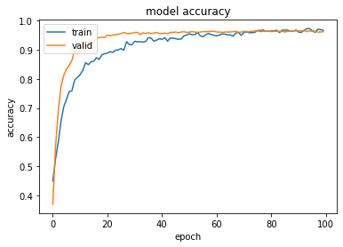

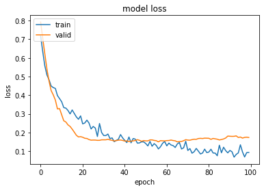

```
Loss is: 0.23324905335903168
Accuracy is: 0.9576008319854736
```

```python
#Nodes=150; Dropout Rate=0.5; Epochs=100; Batch Size=50
seed_everything(1000)

model = model = tf.keras.Sequential([
        tf.keras.layers.Input(N_FEATURES),
        tf.keras.layers.BatchNormalization(),
        tf.keras.layers.Dropout(0.5),
        tfa.layers.WeightNormalization(tf.keras.layers.Dense(150, activation="relu")),
        tf.keras.layers.BatchNormalization(),
        tf.keras.layers.Dropout(0.5),
        tfa.layers.WeightNormalization(tf.keras.layers.Dense(1, activation="sigmoid"))
    ])

model.compile(optimizer=tf.keras.optimizers.Adam(learning_rate = 0.001), loss='binary_crossentropy',
                  metrics=["accuracy"])

history=model.fit(x_train_df, y_train, epochs=100, batch_size=50, verbose=0,
                        validation_split=0.2, shuffle=True, class_weight=class_weight)

# summarize history for accuracy
plt.plot(history.history['accuracy'])
plt.plot(history.history['val_accuracy'])
plt.title('model accuracy')
plt.ylabel('accuracy')
plt.xlabel('epoch')
plt.legend(['train', 'valid'], loc='upper left')
plt.show()

# summarize history for loss
plt.plot(history.history['loss'])
plt.plot(history.history['val_loss'])
plt.title('model loss')
plt.ylabel('loss')
plt.xlabel('epoch')
plt.legend(['train', 'valid'], loc='upper left')
plt.show()

final_model_eval=model.evaluate(x_test_df, y_test, batch_size=50)
print("Loss is:",final_model_eval[0])
print("Accuracy is:",final_model_eval[1])
```

The learning curve for this model showed overfitting. I tried to decrease the number of epochs to 50.

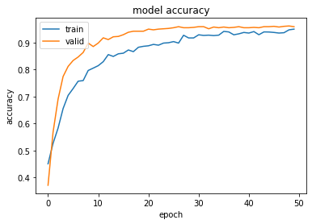

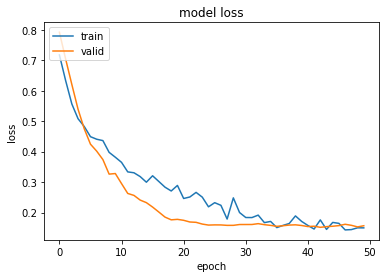

```
Loss is: 0.2051302194595337
Accuracy is: 0.9565666913986206
```

```python
#Nodes=150; Dropout Rate=0.5; Epochs=50; Batch Size=50

seed_everything(1000)

model = model = tf.keras.Sequential([
        tf.keras.layers.Input(N_FEATURES),
        tf.keras.layers.BatchNormalization(),
        tf.keras.layers.Dropout(0.5),
        tfa.layers.WeightNormalization(tf.keras.layers.Dense(150, activation="relu")),
        tf.keras.layers.BatchNormalization(),
        tf.keras.layers.Dropout(0.5),
        tfa.layers.WeightNormalization(tf.keras.layers.Dense(1, activation="sigmoid"))
    ])

model.compile(optimizer=tf.keras.optimizers.Adam(learning_rate = 0.001), loss='binary_crossentropy',
                  metrics=["accuracy"])

history=model.fit(x_train_df, y_train, epochs=50, batch_size=50, verbose=0,
                        validation_split=0.2, shuffle=True, class_weight=class_weight)

# summarize history for accuracy
plt.plot(history.history['accuracy'])
plt.plot(history.history['val_accuracy'])
plt.title('model accuracy')
plt.ylabel('accuracy')
plt.xlabel('epoch')
plt.legend(['train', 'valid'], loc='upper left')
plt.show()

# summarize history for loss
plt.plot(history.history['loss'])
plt.plot(history.history['val_loss'])
plt.title('model loss')
plt.ylabel('loss')
plt.xlabel('epoch')
plt.legend(['train', 'valid'], loc='upper left')
plt.show()

final_model_eval=model.evaluate(x_test_df, y_test, batch_size=50)
print("Loss is:",final_model_eval[0])
print("Accuracy is:",final_model_eval[1])
```

The learning curve for this model seemed okay, so I predicted values using this model.

```python
nn_predictions=model.predict(x_test_df)
```

```python
nn_predict(0.50)
nn_predict(0.40)
nn_predict(0.35)
nn_predict(0.30)
nn_predict(0.20)
nn_predict(0.10)
nn_predict(0.05)
nn_predict(0.01)
nn_predict(0.005)
nn_predict(0.004)
nn_predict(0.003)
```

```
Confusion matrix when threshold= 0.5
 [[920   9]
 [ 33   5]]
Sensitivity/recall when threshold = 0.5 : 0.13157894736842105
Specificity when threshold = 0.5 : 0.9903121636167922
Precision when threshold = 0.5 : 0.35714285714285715
F1 Score when threshold = 0.5 : 0.1923076923076923
Accuracy when threshold = 0.5 : 0.9565667011375388


Confusion matrix when threshold= 0.4
 [[916  13]
 [ 33   5]]
Sensitivity/recall when threshold = 0.4 : 0.13157894736842105
Specificity when threshold = 0.4 : 0.9860064585575888
Precision when threshold = 0.4 : 0.2777777777777778
F1 Score when threshold = 0.4 : 0.17857142857142858
Accuracy when threshold = 0.4 : 0.9524301964839711


Confusion matrix when threshold= 0.35
 [[915  14]
 [ 33   5]]
Sensitivity/recall when threshold = 0.35 : 0.13157894736842105
Specificity when threshold = 0.35 : 0.984930032292788
Precision when threshold = 0.35 : 0.2631578947368421
F1 Score when threshold = 0.35 : 0.17543859649122803
Accuracy when threshold = 0.35 : 0.9513960703205792


Confusion matrix when threshold= 0.3
 [[913  16]
 [ 32   6]]
Sensitivity/recall when threshold = 0.3 : 0.15789473684210525
Specificity when threshold = 0.3 : 0.9827771797631862
Precision when threshold = 0.3 : 0.2727272727272727
F1 Score when threshold = 0.3 : 0.19999999999999998
Accuracy when threshold = 0.3 : 0.9503619441571872


```

[output cut: 53 more lines]

```
Sensitivity/recall when threshold = 0.004 : 0.8947368421052632
Specificity when threshold = 0.004 : 0.3767491926803014
Precision when threshold = 0.004 : 0.05546492659053834
F1 Score when threshold = 0.004 : 0.10445468509984639
Accuracy when threshold = 0.004 : 0.39710444674250256


Confusion matrix when threshold= 0.003
 [[292 637]
 [  3  35]]
Sensitivity/recall when threshold = 0.003 : 0.9210526315789473
Specificity when threshold = 0.003 : 0.3143164693218515
Precision when threshold = 0.003 : 0.052083333333333336
F1 Score when threshold = 0.003 : 0.09859154929577466
Accuracy when threshold = 0.003 : 0.33815925542916236
```

I again examined specificity when sensitivity was equal to 0.92. Specificity was lower when sensitivity was equal to 0.92 (0.31) than in the last model that I tried (0.45), so I stayed with the last model. I will edit each portion of the last model (Nodes=100; Dropout Rate=0.5; Epochs=100; Batch Size=50) up and down while leaving the rest of the model the same to see if it improves performance. If not, I will stick with that model.

1) Nodes Up: We already know that this does not help (see above)

2) Nodes Down: Did not help (see below)

3) Dropout Rate Up: Helped (see below)

4) Dropout Rate Down: I already played with a lower dropout rate (0.4) and it didn't seem to help (see above)

5) Epochs Up: Did not help (see below)

6) Epochs Down: Did not help (see below)

7) Batch Size Up: Did not help (see below)

8) Batch Size Down: Did not help (see below)

Based on this additional analysis, I chose to use the following model: Nodes=100; Dropout Rate=0.6; Epochs=100; Batch Size=50

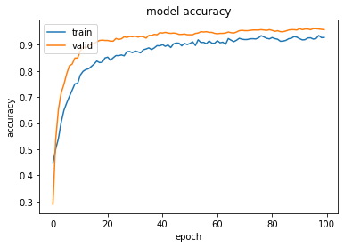

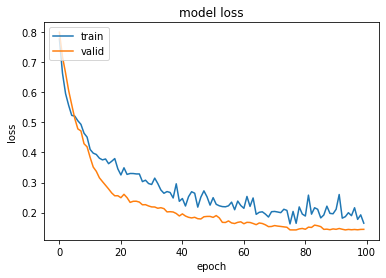

```
Loss is: 0.18577849864959717
Accuracy is: 0.9513960480690002
```

```python
#Nodes DOWN
#Original model: Nodes=100; Dropout Rate=0.5; Epochs=100; Batch Size=50
#New model: Nodes=50; Dropout Rate=0.5; Epochs=100; Batch Size=50
seed_everything(1000)

model = model = tf.keras.Sequential([
        tf.keras.layers.Input(N_FEATURES),
        tf.keras.layers.BatchNormalization(),
        tf.keras.layers.Dropout(0.5),
        tfa.layers.WeightNormalization(tf.keras.layers.Dense(50, activation="relu")),
        tf.keras.layers.BatchNormalization(),
        tf.keras.layers.Dropout(0.5),
        tfa.layers.WeightNormalization(tf.keras.layers.Dense(1, activation="sigmoid"))
    ])

model.compile(optimizer=tf.keras.optimizers.Adam(learning_rate = 0.001), loss='binary_crossentropy',
                  metrics=["accuracy"])

history=model.fit(x_train_df, y_train, epochs=100, batch_size=50, verbose=0,
                        validation_split=0.2, shuffle=True, class_weight=class_weight)

# summarize history for accuracy
plt.plot(history.history['accuracy'])
plt.plot(history.history['val_accuracy'])
plt.title('model accuracy')
plt.ylabel('accuracy')
plt.xlabel('epoch')
plt.legend(['train', 'valid'], loc='upper left')
plt.show()

# summarize history for loss
plt.plot(history.history['loss'])
plt.plot(history.history['val_loss'])
plt.title('model loss')
plt.ylabel('loss')
plt.xlabel('epoch')
plt.legend(['train', 'valid'], loc='upper left')
plt.show()

final_model_eval=model.evaluate(x_test_df, y_test, batch_size=50)
print("Loss is:",final_model_eval[0])
print("Accuracy is:",final_model_eval[1])
```

The learning curve for this model seemed okay, so I predicted values using this model.

```python
nn_predictions=model.predict(x_test_df)
```

```python
nn_predict(0.50)
nn_predict(0.40)
nn_predict(0.35)
nn_predict(0.30)
nn_predict(0.20)
nn_predict(0.10)
nn_predict(0.05)
nn_predict(0.04)
nn_predict(0.03)
nn_predict(0.02)
nn_predict(0.01)
nn_predict(0.009)
```

```
Confusion matrix when threshold= 0.5
 [[915  14]
 [ 33   5]]
Sensitivity/recall when threshold = 0.5 : 0.13157894736842105
Specificity when threshold = 0.5 : 0.984930032292788
Precision when threshold = 0.5 : 0.2631578947368421
F1 Score when threshold = 0.5 : 0.17543859649122803
Accuracy when threshold = 0.5 : 0.9513960703205792


Confusion matrix when threshold= 0.4
 [[908  21]
 [ 32   6]]
Sensitivity/recall when threshold = 0.4 : 0.15789473684210525
Specificity when threshold = 0.4 : 0.9773950484391819
Precision when threshold = 0.4 : 0.2222222222222222
F1 Score when threshold = 0.4 : 0.18461538461538463
Accuracy when threshold = 0.4 : 0.9451913133402275


Confusion matrix when threshold= 0.35
 [[904  25]
 [ 32   6]]
Sensitivity/recall when threshold = 0.35 : 0.15789473684210525
Specificity when threshold = 0.35 : 0.9730893433799784
Precision when threshold = 0.35 : 0.1935483870967742
F1 Score when threshold = 0.35 : 0.17391304347826086
Accuracy when threshold = 0.35 : 0.9410548086866598


Confusion matrix when threshold= 0.3
 [[897  32]
 [ 29   9]]
Sensitivity/recall when threshold = 0.3 : 0.23684210526315788
Specificity when threshold = 0.3 : 0.9655543595263725
Precision when threshold = 0.3 : 0.21951219512195122
F1 Score when threshold = 0.3 : 0.2278481012658228
Accuracy when threshold = 0.3 : 0.9369183040330921


```

[output cut: 63 more lines]

```
Sensitivity/recall when threshold = 0.01 : 0.9210526315789473
Specificity when threshold = 0.01 : 0.3627556512378902
Precision when threshold = 0.01 : 0.05582137161084529
F1 Score when threshold = 0.01 : 0.10526315789473684
Accuracy when threshold = 0.01 : 0.3846949327817994


Confusion matrix when threshold= 0.009
 [[327 602]
 [  3  35]]
Sensitivity/recall when threshold = 0.009 : 0.9210526315789473
Specificity when threshold = 0.009 : 0.3519913885898816
Precision when threshold = 0.009 : 0.054945054945054944
F1 Score when threshold = 0.009 : 0.1037037037037037
Accuracy when threshold = 0.009 : 0.37435367114788004
```

This did not help to increase specificity when sensitivity=0.92.

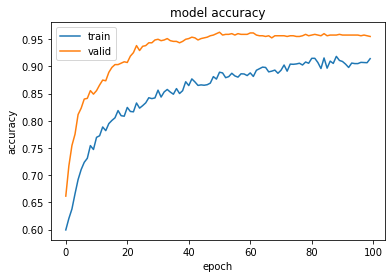

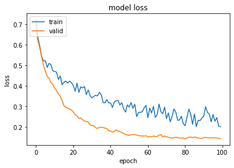

```
Loss is: 0.1561194807291031
Accuracy is: 0.9544984698295593
```

```python
#Dropout rate UP
#Original model: Nodes=100; Dropout Rate=0.5; Epochs=100; Batch Size=50
#New model: Nodes=100; Dropout Rate=0.6; Epochs=100; Batch Size=50
seed_everything(1000)

model = model = tf.keras.Sequential([
        tf.keras.layers.Input(N_FEATURES),
        tf.keras.layers.BatchNormalization(),
        tf.keras.layers.Dropout(0.6),
        tfa.layers.WeightNormalization(tf.keras.layers.Dense(100, activation="relu")),
        tf.keras.layers.BatchNormalization(),
        tf.keras.layers.Dropout(0.6),
        tfa.layers.WeightNormalization(tf.keras.layers.Dense(1, activation="sigmoid"))
    ])

model.compile(optimizer=tf.keras.optimizers.Adam(learning_rate = 0.001), loss='binary_crossentropy',
                  metrics=["accuracy"])

history=model.fit(x_train_df, y_train, epochs=100, batch_size=50, verbose=0,
                        validation_split=0.2, shuffle=True, class_weight=class_weight)

# summarize history for accuracy
plt.plot(history.history['accuracy'])
plt.plot(history.history['val_accuracy'])
plt.title('model accuracy')
plt.ylabel('accuracy')
plt.xlabel('epoch')
plt.legend(['train', 'valid'], loc='upper left')
plt.show()

# summarize history for loss
plt.plot(history.history['loss'])
plt.plot(history.history['val_loss'])
plt.title('model loss')
plt.ylabel('loss')
plt.xlabel('epoch')
plt.legend(['train', 'valid'], loc='upper left')
plt.show()

final_model_eval=model.evaluate(x_test_df, y_test, batch_size=50)
print("Loss is:",final_model_eval[0])
print("Accuracy is:",final_model_eval[1])
```

The learning curve for this model seemed okay, so I predicted values using this model.

```python
nn_predictions=model.predict(x_test_df)
```

```python
nn_predict(0.50)
nn_predict(0.40)
nn_predict(0.35)
nn_predict(0.30)
nn_predict(0.20)
nn_predict(0.10)
nn_predict(0.05)
nn_predict(0.04)
nn_predict(0.03)
```

```
Confusion matrix when threshold= 0.5
 [[921   8]
 [ 36   2]]
Sensitivity/recall when threshold = 0.5 : 0.05263157894736842
Specificity when threshold = 0.5 : 0.9913885898815931
Precision when threshold = 0.5 : 0.2
F1 Score when threshold = 0.5 : 0.08333333333333333
Accuracy when threshold = 0.5 : 0.954498448810755


Confusion matrix when threshold= 0.4
 [[918  11]
 [ 35   3]]
Sensitivity/recall when threshold = 0.4 : 0.07894736842105263
Specificity when threshold = 0.4 : 0.9881593110871906
Precision when threshold = 0.4 : 0.21428571428571427
F1 Score when threshold = 0.4 : 0.11538461538461539
Accuracy when threshold = 0.4 : 0.9524301964839711


Confusion matrix when threshold= 0.35
 [[914  15]
 [ 32   6]]
Sensitivity/recall when threshold = 0.35 : 0.15789473684210525
Specificity when threshold = 0.35 : 0.9838536060279871
Precision when threshold = 0.35 : 0.2857142857142857
F1 Score when threshold = 0.35 : 0.2033898305084746
Accuracy when threshold = 0.35 : 0.9513960703205792


Confusion matrix when threshold= 0.3
 [[904  25]
 [ 31   7]]
Sensitivity/recall when threshold = 0.3 : 0.18421052631578946
Specificity when threshold = 0.3 : 0.9730893433799784
Precision when threshold = 0.3 : 0.21875
F1 Score when threshold = 0.3 : 0.19999999999999998
Accuracy when threshold = 0.3 : 0.9420889348500517


```

[output cut: 33 more lines]

```
Sensitivity/recall when threshold = 0.04 : 0.8157894736842105
Specificity when threshold = 0.04 : 0.6221743810548978
Precision when threshold = 0.04 : 0.08115183246073299
F1 Score when threshold = 0.04 : 0.14761904761904762
Accuracy when threshold = 0.04 : 0.6297828335056876


Confusion matrix when threshold= 0.03
 [[504 425]
 [  3  35]]
Sensitivity/recall when threshold = 0.03 : 0.9210526315789473
Specificity when threshold = 0.03 : 0.542518837459634
Precision when threshold = 0.03 : 0.07608695652173914
F1 Score when threshold = 0.03 : 0.14056224899598393
Accuracy when threshold = 0.03 : 0.5573940020682523
```

This did help with specificity when sensitivity=0.92 (0.54 in new model compared to 0.45 in old model).

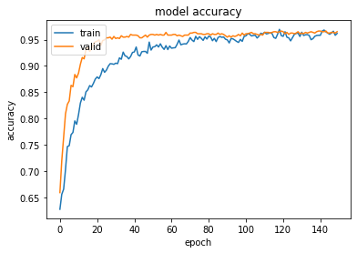

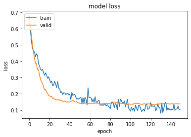

```
Loss is: 0.19393233954906464
Accuracy is: 0.9565666913986206
```

```python
#Epochs UP
#Original model: Nodes=100; Dropout Rate=0.5; Epochs=100; Batch Size=50
#New model: Nodes=100; Dropout Rate=0.5; Epochs=150; Batch Size=50
seed_everything(1000)

model = model = tf.keras.Sequential([
        tf.keras.layers.Input(N_FEATURES),
        tf.keras.layers.BatchNormalization(),
        tf.keras.layers.Dropout(0.5),
        tfa.layers.WeightNormalization(tf.keras.layers.Dense(100, activation="relu")),
        tf.keras.layers.BatchNormalization(),
        tf.keras.layers.Dropout(0.5),
        tfa.layers.WeightNormalization(tf.keras.layers.Dense(1, activation="sigmoid"))
    ])

model.compile(optimizer=tf.keras.optimizers.Adam(learning_rate = 0.001), loss='binary_crossentropy',
                  metrics=["accuracy"])

history=model.fit(x_train_df, y_train, epochs=150, batch_size=50, verbose=0,
                        validation_split=0.2, shuffle=True, class_weight=class_weight)

# summarize history for accuracy
plt.plot(history.history['accuracy'])
plt.plot(history.history['val_accuracy'])
plt.title('model accuracy')
plt.ylabel('accuracy')
plt.xlabel('epoch')
plt.legend(['train', 'valid'], loc='upper left')
plt.show()

# summarize history for loss
plt.plot(history.history['loss'])
plt.plot(history.history['val_loss'])
plt.title('model loss')
plt.ylabel('loss')
plt.xlabel('epoch')
plt.legend(['train', 'valid'], loc='upper left')
plt.show()

final_model_eval=model.evaluate(x_test_df, y_test, batch_size=50)
print("Loss is:",final_model_eval[0])
print("Accuracy is:",final_model_eval[1])
```

The learning curve for this model seemed okay, so I predicted values using this model.

```python
nn_predictions=model.predict(x_test_df)
```

```python
nn_predict(0.50)
nn_predict(0.40)
nn_predict(0.35)
nn_predict(0.30)
nn_predict(0.20)
nn_predict(0.10)
nn_predict(0.05)
nn_predict(0.01)
nn_predict(0.009)
nn_predict(0.008)
nn_predict(0.007)
nn_predict(0.006)
nn_predict(0.005)
nn_predict(0.001)
```

```
Confusion matrix when threshold= 0.5
 [[923   6]
 [ 36   2]]
Sensitivity/recall when threshold = 0.5 : 0.05263157894736842
Specificity when threshold = 0.5 : 0.9935414424111948
Precision when threshold = 0.5 : 0.25
F1 Score when threshold = 0.5 : 0.08695652173913043
Accuracy when threshold = 0.5 : 0.9565667011375388


Confusion matrix when threshold= 0.4
 [[923   6]
 [ 36   2]]
Sensitivity/recall when threshold = 0.4 : 0.05263157894736842
Specificity when threshold = 0.4 : 0.9935414424111948
Precision when threshold = 0.4 : 0.25
F1 Score when threshold = 0.4 : 0.08695652173913043
Accuracy when threshold = 0.4 : 0.9565667011375388


Confusion matrix when threshold= 0.35
 [[922   7]
 [ 36   2]]
Sensitivity/recall when threshold = 0.35 : 0.05263157894736842
Specificity when threshold = 0.35 : 0.9924650161463939
Precision when threshold = 0.35 : 0.2222222222222222
F1 Score when threshold = 0.35 : 0.0851063829787234
Accuracy when threshold = 0.35 : 0.9555325749741469


Confusion matrix when threshold= 0.3
 [[918  11]
 [ 36   2]]
Sensitivity/recall when threshold = 0.3 : 0.05263157894736842
Specificity when threshold = 0.3 : 0.9881593110871906
Precision when threshold = 0.3 : 0.15384615384615385
F1 Score when threshold = 0.3 : 0.0784313725490196
Accuracy when threshold = 0.3 : 0.9513960703205792


```

[output cut: 83 more lines]

```
Sensitivity/recall when threshold = 0.005 : 0.868421052631579
Specificity when threshold = 0.005 : 0.503767491926803
Precision when threshold = 0.005 : 0.06680161943319839
F1 Score when threshold = 0.005 : 0.12406015037593986
Accuracy when threshold = 0.005 : 0.5180972078593589


Confusion matrix when threshold= 0.001
 [[223 706]
 [  3  35]]
Sensitivity/recall when threshold = 0.001 : 0.9210526315789473
Specificity when threshold = 0.001 : 0.24004305705059203
Precision when threshold = 0.001 : 0.04723346828609987
F1 Score when threshold = 0.001 : 0.08985879332477535
Accuracy when threshold = 0.001 : 0.26680455015511895
```

This did not help with specificity when sensitivity=0.92.

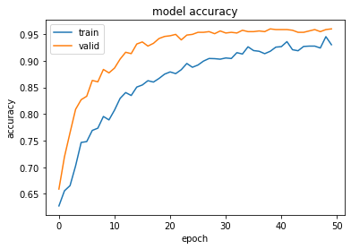

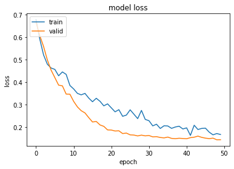

```
Loss is: 0.17991675436496735
Accuracy is: 0.9544984698295593
```

```python
#Epochs DOWN
#Original model: Nodes=100; Dropout Rate=0.5; Epochs=100; Batch Size=50
#New model: Nodes=100; Dropout Rate=0.5; Epochs=50; Batch Size=50
seed_everything(1000)

model = model = tf.keras.Sequential([
        tf.keras.layers.Input(N_FEATURES),
        tf.keras.layers.BatchNormalization(),
        tf.keras.layers.Dropout(0.5),
        tfa.layers.WeightNormalization(tf.keras.layers.Dense(100, activation="relu")),
        tf.keras.layers.BatchNormalization(),
        tf.keras.layers.Dropout(0.5),
        tfa.layers.WeightNormalization(tf.keras.layers.Dense(1, activation="sigmoid"))
    ])

model.compile(optimizer=tf.keras.optimizers.Adam(learning_rate = 0.001), loss='binary_crossentropy',
                  metrics=["accuracy"])

history=model.fit(x_train_df, y_train, epochs=50, batch_size=50, verbose=0,
                        validation_split=0.2, shuffle=True, class_weight=class_weight)

# summarize history for accuracy
plt.plot(history.history['accuracy'])
plt.plot(history.history['val_accuracy'])
plt.title('model accuracy')
plt.ylabel('accuracy')
plt.xlabel('epoch')
plt.legend(['train', 'valid'], loc='upper left')
plt.show()

# summarize history for loss
plt.plot(history.history['loss'])
plt.plot(history.history['val_loss'])
plt.title('model loss')
plt.ylabel('loss')
plt.xlabel('epoch')
plt.legend(['train', 'valid'], loc='upper left')
plt.show()

final_model_eval=model.evaluate(x_test_df, y_test, batch_size=50)
print("Loss is:",final_model_eval[0])
print("Accuracy is:",final_model_eval[1])
```

The learning curve for this model seemed okay, so I predicted values using this model.

```python
nn_predictions=model.predict(x_test_df)
```

```python
nn_predict(0.50)
nn_predict(0.40)
nn_predict(0.35)
nn_predict(0.30)
nn_predict(0.20)
nn_predict(0.10)
nn_predict(0.05)
nn_predict(0.01)
nn_predict(0.009)
nn_predict(0.008)
nn_predict(0.007)
nn_predict(0.006)
```

```
Confusion matrix when threshold= 0.5
 [[917  12]
 [ 32   6]]
Sensitivity/recall when threshold = 0.5 : 0.15789473684210525
Specificity when threshold = 0.5 : 0.9870828848223897
Precision when threshold = 0.5 : 0.3333333333333333
F1 Score when threshold = 0.5 : 0.21428571428571427
Accuracy when threshold = 0.5 : 0.954498448810755


Confusion matrix when threshold= 0.4
 [[910  19]
 [ 31   7]]
Sensitivity/recall when threshold = 0.4 : 0.18421052631578946
Specificity when threshold = 0.4 : 0.9795479009687836
Precision when threshold = 0.4 : 0.2692307692307692
F1 Score when threshold = 0.4 : 0.21875
Accuracy when threshold = 0.4 : 0.9482936918304034


Confusion matrix when threshold= 0.35
 [[909  20]
 [ 30   8]]
Sensitivity/recall when threshold = 0.35 : 0.21052631578947367
Specificity when threshold = 0.35 : 0.9784714747039828
Precision when threshold = 0.35 : 0.2857142857142857
F1 Score when threshold = 0.35 : 0.24242424242424243
Accuracy when threshold = 0.35 : 0.9482936918304034


Confusion matrix when threshold= 0.3
 [[904  25]
 [ 30   8]]
Sensitivity/recall when threshold = 0.3 : 0.21052631578947367
Specificity when threshold = 0.3 : 0.9730893433799784
Precision when threshold = 0.3 : 0.24242424242424243
F1 Score when threshold = 0.3 : 0.22535211267605634
Accuracy when threshold = 0.3 : 0.9431230610134437


```

[output cut: 63 more lines]

```
Sensitivity/recall when threshold = 0.007 : 0.9210526315789473
Specificity when threshold = 0.007 : 0.34768568353067814
Precision when threshold = 0.007 : 0.054602184087363496
F1 Score when threshold = 0.007 : 0.10309278350515465
Accuracy when threshold = 0.007 : 0.3702171664943123


Confusion matrix when threshold= 0.006
 [[297 632]
 [  3  35]]
Sensitivity/recall when threshold = 0.006 : 0.9210526315789473
Specificity when threshold = 0.006 : 0.31969860064585576
Precision when threshold = 0.006 : 0.05247376311844078
F1 Score when threshold = 0.006 : 0.09929078014184398
Accuracy when threshold = 0.006 : 0.34332988624612204
```

This did not help with specificity at sensitivity=0.92.

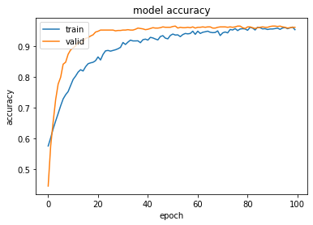

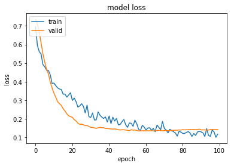

```
Loss is: 0.17578935623168945
Accuracy is: 0.9544984698295593
```

```python
#Batches UP
#Original model: Nodes=100; Dropout Rate=0.5; Epochs=100; Batch Size=50
#New model: Nodes=100; Dropout Rate=0.5; Epochs=100; Batch Size=100
seed_everything(1000)

model = model = tf.keras.Sequential([
        tf.keras.layers.Input(N_FEATURES),
        tf.keras.layers.BatchNormalization(),
        tf.keras.layers.Dropout(0.5),
        tfa.layers.WeightNormalization(tf.keras.layers.Dense(100, activation="relu")),
        tf.keras.layers.BatchNormalization(),
        tf.keras.layers.Dropout(0.5),
        tfa.layers.WeightNormalization(tf.keras.layers.Dense(1, activation="sigmoid"))
    ])

model.compile(optimizer=tf.keras.optimizers.Adam(learning_rate = 0.001), loss='binary_crossentropy',
                  metrics=["accuracy"])

history=model.fit(x_train_df, y_train, epochs=100, batch_size=100, verbose=0,
                        validation_split=0.2, shuffle=True, class_weight=class_weight)

# summarize history for accuracy
plt.plot(history.history['accuracy'])
plt.plot(history.history['val_accuracy'])
plt.title('model accuracy')
plt.ylabel('accuracy')
plt.xlabel('epoch')
plt.legend(['train', 'valid'], loc='upper left')
plt.show()

# summarize history for loss
plt.plot(history.history['loss'])
plt.plot(history.history['val_loss'])
plt.title('model loss')
plt.ylabel('loss')
plt.xlabel('epoch')
plt.legend(['train', 'valid'], loc='upper left')
plt.show()

final_model_eval=model.evaluate(x_test_df, y_test, batch_size=100)
print("Loss is:",final_model_eval[0])
print("Accuracy is:",final_model_eval[1])
```

The learning curve for this model seemed okay, so I predicted values using this model.

```python
nn_predictions=model.predict(x_test_df)
```

```python
nn_predict(0.50)
nn_predict(0.40)
nn_predict(0.35)
nn_predict(0.30)
nn_predict(0.20)
nn_predict(0.10)
nn_predict(0.05)
nn_predict(0.01)
nn_predict(0.005)
nn_predict(0.004)
nn_predict(0.003)
```

```
Confusion matrix when threshold= 0.5
 [[921   8]
 [ 36   2]]
Sensitivity/recall when threshold = 0.5 : 0.05263157894736842
Specificity when threshold = 0.5 : 0.9913885898815931
Precision when threshold = 0.5 : 0.2
F1 Score when threshold = 0.5 : 0.08333333333333333
Accuracy when threshold = 0.5 : 0.954498448810755


Confusion matrix when threshold= 0.4
 [[920   9]
 [ 36   2]]
Sensitivity/recall when threshold = 0.4 : 0.05263157894736842
Specificity when threshold = 0.4 : 0.9903121636167922
Precision when threshold = 0.4 : 0.18181818181818182
F1 Score when threshold = 0.4 : 0.08163265306122448
Accuracy when threshold = 0.4 : 0.953464322647363


Confusion matrix when threshold= 0.35
 [[920   9]
 [ 35   3]]
Sensitivity/recall when threshold = 0.35 : 0.07894736842105263
Specificity when threshold = 0.35 : 0.9903121636167922
Precision when threshold = 0.35 : 0.25
F1 Score when threshold = 0.35 : 0.11999999999999998
Accuracy when threshold = 0.35 : 0.954498448810755


Confusion matrix when threshold= 0.3
 [[919  10]
 [ 35   3]]
Sensitivity/recall when threshold = 0.3 : 0.07894736842105263
Specificity when threshold = 0.3 : 0.9892357373519914
Precision when threshold = 0.3 : 0.23076923076923078
F1 Score when threshold = 0.3 : 0.11764705882352941
Accuracy when threshold = 0.3 : 0.953464322647363


```

[output cut: 53 more lines]

```
Sensitivity/recall when threshold = 0.004 : 0.8947368421052632
Specificity when threshold = 0.004 : 0.418729817007535
Precision when threshold = 0.004 : 0.059233449477351915
F1 Score when threshold = 0.004 : 0.11111111111111112
Accuracy when threshold = 0.004 : 0.43743536711478803


Confusion matrix when threshold= 0.003
 [[322 607]
 [  3  35]]
Sensitivity/recall when threshold = 0.003 : 0.9210526315789473
Specificity when threshold = 0.003 : 0.34660925726587727
Precision when threshold = 0.003 : 0.05451713395638629
F1 Score when threshold = 0.003 : 0.10294117647058823
Accuracy when threshold = 0.003 : 0.36918304033092036
```

This did not help with specificity at sensitivity=0.92.

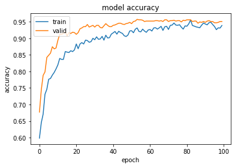

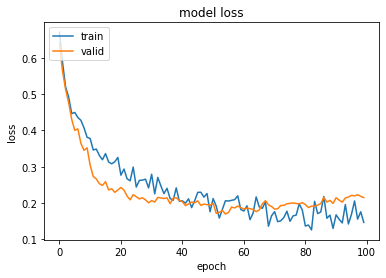

```
Loss is: 0.24473322927951813
Accuracy is: 0.9482936859130859
```

```python
#Batches DOWN
#Original model: Nodes=100; Dropout Rate=0.5; Epochs=100; Batch Size=50
#New model: Nodes=100; Dropout Rate=0.5; Epochs=100; Batch Size=25
seed_everything(1000)

model = model = tf.keras.Sequential([
        tf.keras.layers.Input(N_FEATURES),
        tf.keras.layers.BatchNormalization(),
        tf.keras.layers.Dropout(0.5),
        tfa.layers.WeightNormalization(tf.keras.layers.Dense(100, activation="relu")),
        tf.keras.layers.BatchNormalization(),
        tf.keras.layers.Dropout(0.5),
        tfa.layers.WeightNormalization(tf.keras.layers.Dense(1, activation="sigmoid"))
    ])

model.compile(optimizer=tf.keras.optimizers.Adam(learning_rate = 0.001), loss='binary_crossentropy',
                  metrics=["accuracy"])

history=model.fit(x_train_df, y_train, epochs=100, batch_size=25, verbose=0,
                        validation_split=0.2, shuffle=True, class_weight=class_weight)

# summarize history for accuracy
plt.plot(history.history['accuracy'])
plt.plot(history.history['val_accuracy'])
plt.title('model accuracy')
plt.ylabel('accuracy')
plt.xlabel('epoch')
plt.legend(['train', 'valid'], loc='upper left')
plt.show()

# summarize history for loss
plt.plot(history.history['loss'])
plt.plot(history.history['val_loss'])
plt.title('model loss')
plt.ylabel('loss')
plt.xlabel('epoch')
plt.legend(['train', 'valid'], loc='upper left')
plt.show()

final_model_eval=model.evaluate(x_test_df, y_test, batch_size=25)
print("Loss is:",final_model_eval[0])
print("Accuracy is:",final_model_eval[1])
```

The learning curve for this model showed overfitting.

I also tried to add a second hiden layer.

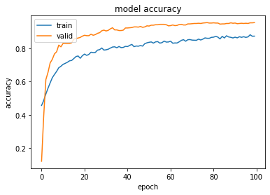

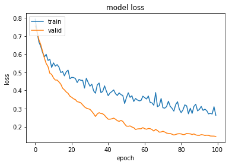

```
Loss is: 0.1589437574148178
Accuracy is: 0.9524301886558533
```

```python
#Original model: Nodes=100; Dropout Rate=0.5; Epochs=100; Batch Size=50
#New model: Nodes=100; Dropout Rate=0.6; Epochs=100; Batch Size=50; 2 layers
seed_everything(1000)

model = model = tf.keras.Sequential([
        tf.keras.layers.Input(N_FEATURES),
        tf.keras.layers.BatchNormalization(),
        tf.keras.layers.Dropout(0.6),
        tfa.layers.WeightNormalization(tf.keras.layers.Dense(100, activation="relu")),
        tf.keras.layers.BatchNormalization(),
        tf.keras.layers.Dropout(0.6),
        tfa.layers.WeightNormalization(tf.keras.layers.Dense(100, activation="relu")),
        tf.keras.layers.BatchNormalization(),
        tf.keras.layers.Dropout(0.6),
        tfa.layers.WeightNormalization(tf.keras.layers.Dense(1, activation="sigmoid"))
    ])

model.compile(optimizer=tf.keras.optimizers.Adam(learning_rate = 0.001), loss='binary_crossentropy',
                  metrics=["accuracy"])

history=model.fit(x_train_df, y_train, epochs=100, batch_size=50, verbose=0,
                        validation_split=0.2, shuffle=True, class_weight=class_weight)

# summarize history for accuracy
plt.plot(history.history['accuracy'])
plt.plot(history.history['val_accuracy'])
plt.title('model accuracy')
plt.ylabel('accuracy')
plt.xlabel('epoch')
plt.legend(['train', 'valid'], loc='upper left')
plt.show()

# summarize history for loss
plt.plot(history.history['loss'])
plt.plot(history.history['val_loss'])
plt.title('model loss')
plt.ylabel('loss')
plt.xlabel('epoch')
plt.legend(['train', 'valid'], loc='upper left')
plt.show()

final_model_eval=model.evaluate(x_test_df, y_test, batch_size=50)
print("Loss is:",final_model_eval[0])
print("Accuracy is:",final_model_eval[1])
```

The learning curve for this model seemed okay, so I predicted values using this model.

```python
nn_predictions=model.predict(x_test_df)
```

```python
nn_predict(0.50)
nn_predict(0.40)
nn_predict(0.35)
nn_predict(0.30)
nn_predict(0.20)
nn_predict(0.10)
nn_predict(0.05)
nn_predict(0.04)
nn_predict(0.03)
nn_predict(0.029)
nn_predict(0.028)
nn_predict(0.027)
nn_predict(0.026)
nn_predict(0.025)
```

```
Confusion matrix when threshold= 0.5
 [[914  15]
 [ 31   7]]
Sensitivity/recall when threshold = 0.5 : 0.18421052631578946
Specificity when threshold = 0.5 : 0.9838536060279871
Precision when threshold = 0.5 : 0.3181818181818182
F1 Score when threshold = 0.5 : 0.23333333333333334
Accuracy when threshold = 0.5 : 0.9524301964839711


Confusion matrix when threshold= 0.4
 [[903  26]
 [ 28  10]]
Sensitivity/recall when threshold = 0.4 : 0.2631578947368421
Specificity when threshold = 0.4 : 0.9720129171151776
Precision when threshold = 0.4 : 0.2777777777777778
F1 Score when threshold = 0.4 : 0.27027027027027023
Accuracy when threshold = 0.4 : 0.9441571871768356


Confusion matrix when threshold= 0.35
 [[895  34]
 [ 27  11]]
Sensitivity/recall when threshold = 0.35 : 0.2894736842105263
Specificity when threshold = 0.35 : 0.9634015069967707
Precision when threshold = 0.35 : 0.24444444444444444
F1 Score when threshold = 0.35 : 0.26506024096385544
Accuracy when threshold = 0.35 : 0.9369183040330921


Confusion matrix when threshold= 0.3
 [[894  35]
 [ 27  11]]
Sensitivity/recall when threshold = 0.3 : 0.2894736842105263
Specificity when threshold = 0.3 : 0.9623250807319699
Precision when threshold = 0.3 : 0.2391304347826087
F1 Score when threshold = 0.3 : 0.2619047619047619
Accuracy when threshold = 0.3 : 0.9358841778697001


```

[output cut: 83 more lines]

```
Sensitivity/recall when threshold = 0.026 : 0.9210526315789473
Specificity when threshold = 0.026 : 0.5231431646932185
Precision when threshold = 0.026 : 0.07322175732217573
F1 Score when threshold = 0.026 : 0.13565891472868216
Accuracy when threshold = 0.026 : 0.5387797311271976


Confusion matrix when threshold= 0.025
 [[483 446]
 [  3  35]]
Sensitivity/recall when threshold = 0.025 : 0.9210526315789473
Specificity when threshold = 0.025 : 0.5199138858988159
Precision when threshold = 0.025 : 0.07276507276507277
F1 Score when threshold = 0.025 : 0.1348747591522158
Accuracy when threshold = 0.025 : 0.5356773526370218
```

This did not help with specificity at sensitivity=0.92 (new model: 0.52 vs. old model: 0.54).